# Prezentacja Warsztaty Badawcze - VIM

Patryk Wrona, Marceli Korbin, Mikołaj Jakubowski

6 kwietnia 2020

# Opis pakietu VIM

Zgodnie z rozwinięciem nazwy, pakiet VIM oferuje rozmaite techniki wizualizacji i imputacji brakujących danych w datasetach. W ramach wizualizacji wprowadza on wiele nowych, ciekawych narzędzi, często pomocnych w rozpoznaniu zawartości i cech danych, a samo wykrywanie brakóW danych wykonywane jest zazwyczaj poprzez statystyczne testy lub modele. Pakietu można używać na danych praktycznie dowolnego typu. Innymi atrakcjami dostępnymi w VIM są m.in. oryginalne zbiory danych przydatne do testowania funkcji, czy funkcje obrabiające lub badające dane, które jeszcze przejrzymy w raporcie.

# Zbiory danych w VIM

VIM udostępnia nam swoje zbiory z brakami danych. Można na nich przetestować znajdujące się w pakiecie funkcje do imputacji danych.

### Lista zbiorów VIM

W VIM dostępne jest 12 poniższych zbiorów danych:

- bcancer
- brittleness
- chorizonDL
- colic
- collisions
- diabetes
- food
- SBS5242
- sleep
- tao
- testdata
- toydataMiss

### Wstępna wizualizacja zbiorów

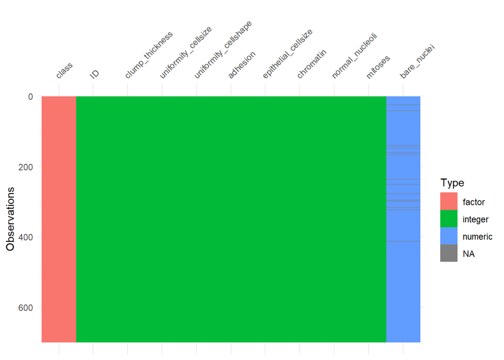

```r
data(bcancer, package = "VIM")
vis_dat(bcancer)
```

Bardzo mało NA. Zbiór do klasyfiacji.

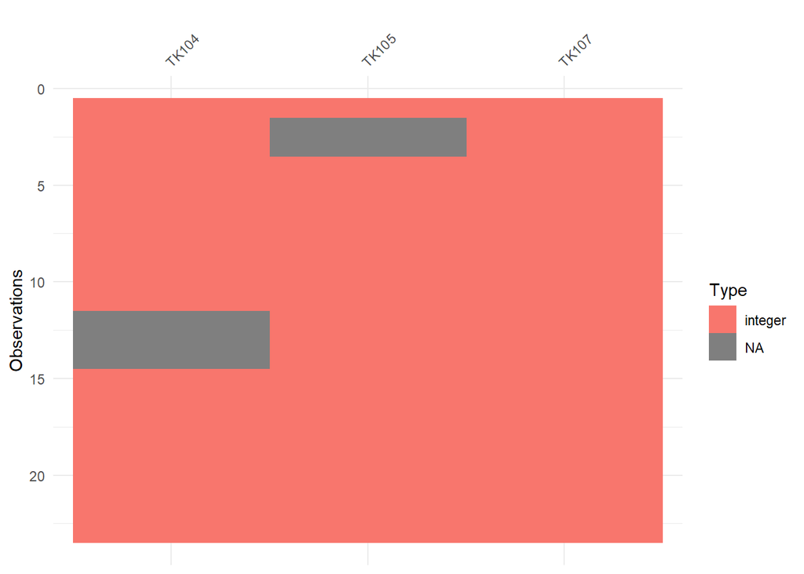

```r
data(brittleness, package = "VIM")
vis_dat(brittleness)
```

Bardzo mały zbiór. Zbiór do regresji.

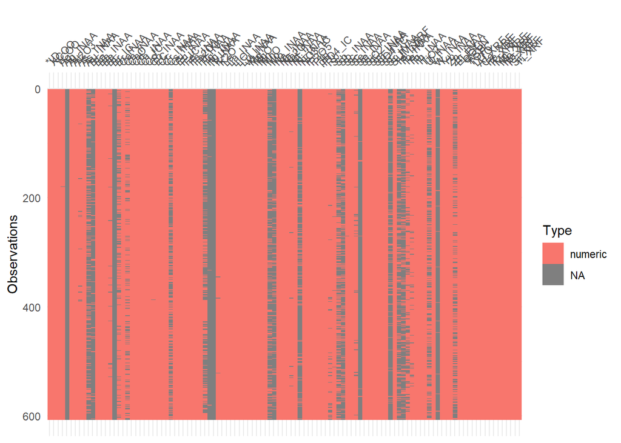

```r
data(chorizonDL, package = "VIM")
vis_dat(chorizonDL)
```

Zbiór do do imputacji danych, regresji.

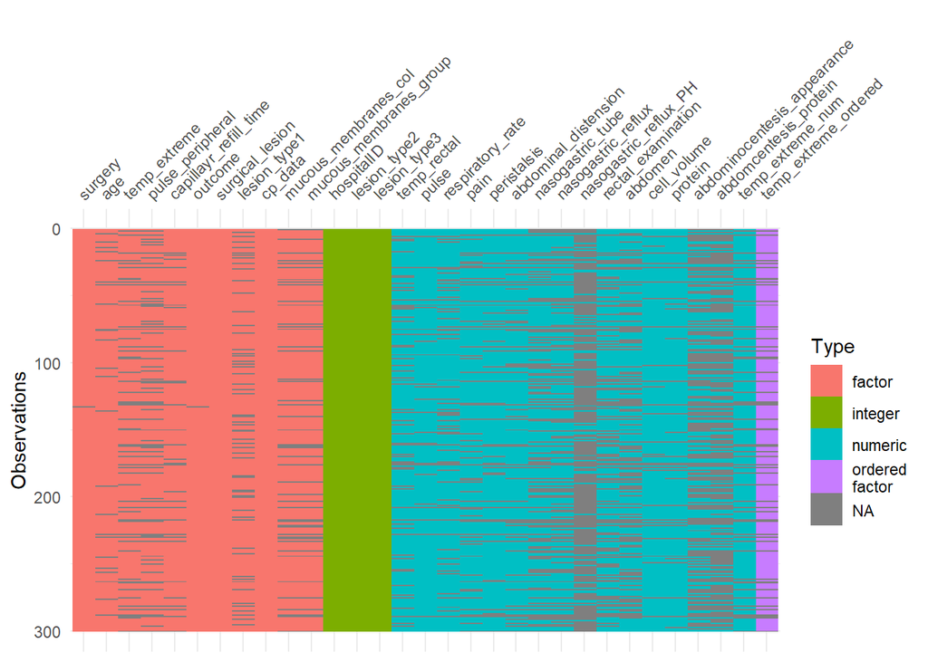

```r
data(colic, package = "VIM")
vis_dat(colic)
```

Wszystkiego po trochu. Dane medyczne o koniach.

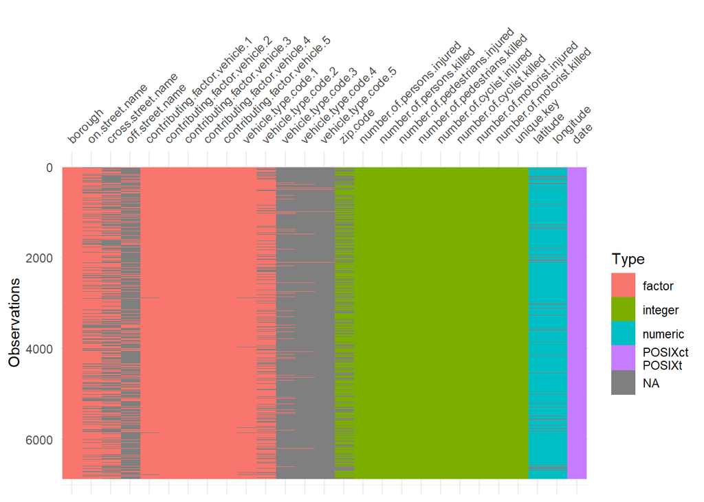

```r
data(collisions, package = "VIM")
vis_dat(collisions)
```

W niektórych kolumnach są same NA, inne da się zaimputować. Zbiór zawiera daty.

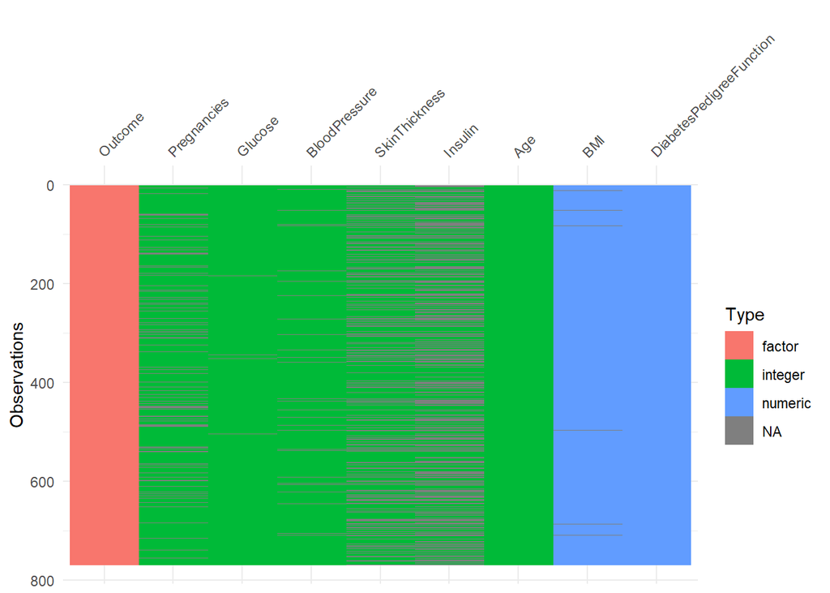

```r
data(diabetes, package = "VIM")
vis_dat(diabetes)
```

Dobry zbiór danych do imputacji & klasyfikacji zmiennej celu Outcome.

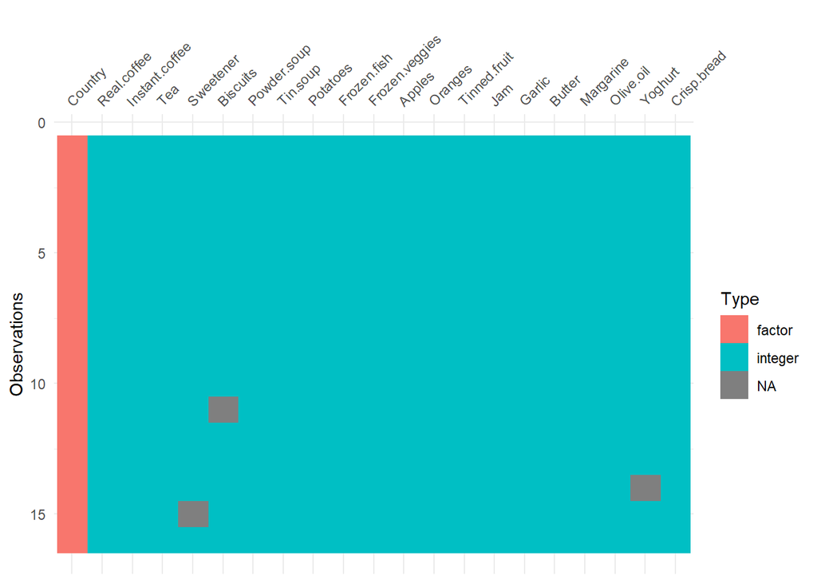

```r
data(food, package = "VIM")
vis_dat(food)
```

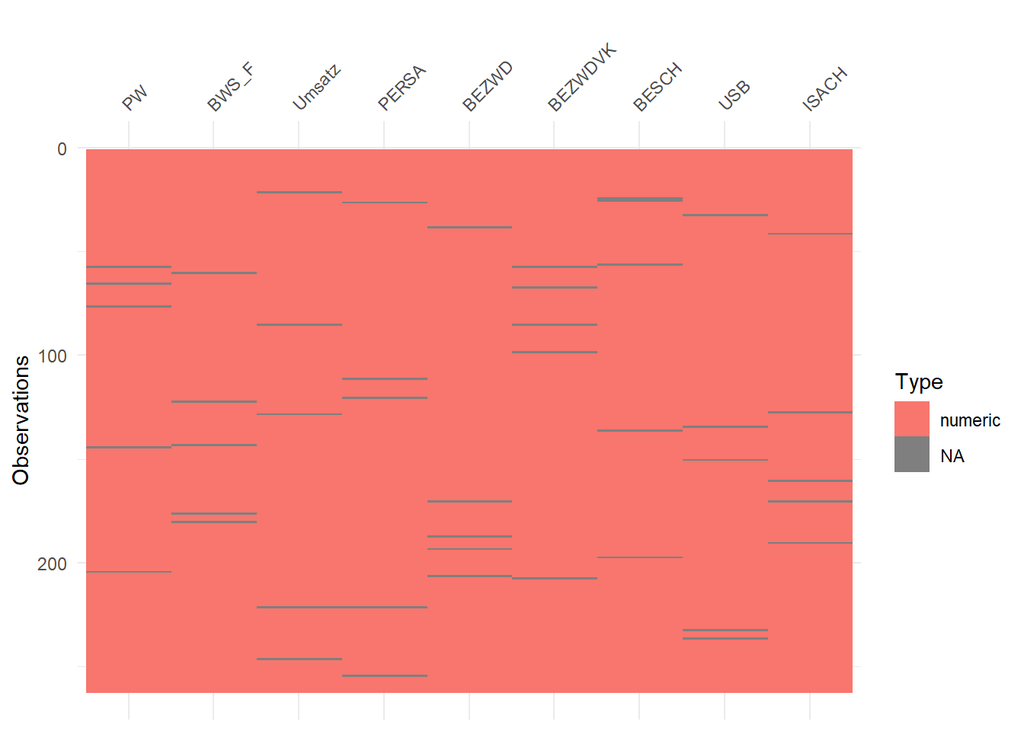

```r
data(SBS5242, package = "VIM")
vis_dat(as.data.frame(SBS5242))
```

Zbiór dobry do regresji liniowej/ kNN w celu imputacji danych. kNN wymaga standaryzacji.

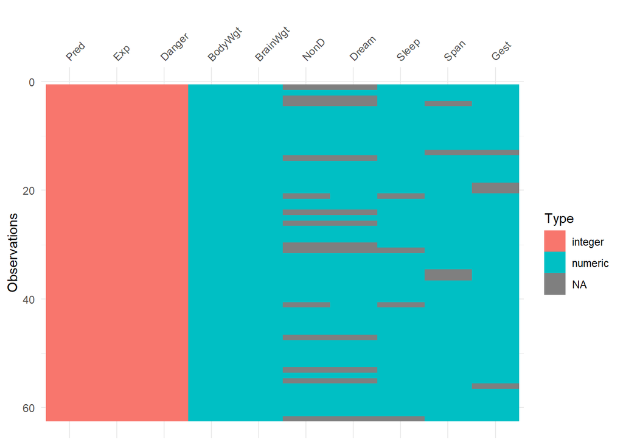

```r
data(sleep, package = "VIM")
vis_dat(sleep)
```

Mały zbiór. Pred, Exp, Danger przyjmują wartości 1,2,3,4,5 .

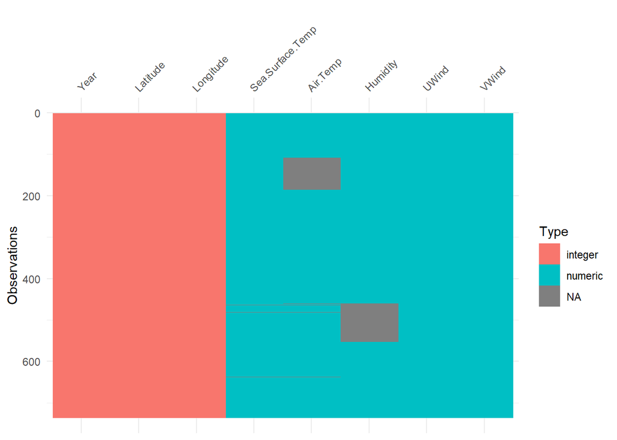

```r
data(tao, package = "VIM")
vis_dat(tao)
```

Year, Longitude, Latitude - 2-3 levelowe factory. Dobre do klasyfikacji.

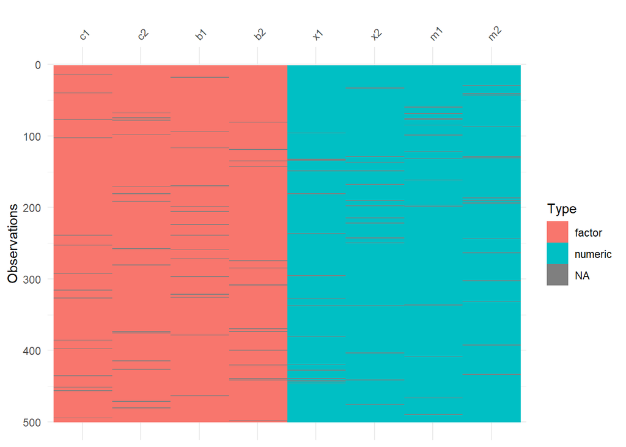

```r
data(testdata, package = "VIM")
vis_dat(testdata$wna)
```

To zbiór ‘wna’. Dołączony jest też zbiór ‘wona’, który jest tym samym zbiorem, ale bez NA. Na tym zbiorze można testować skuteczność technik imputacji danych i porównywać z ‘wona’.

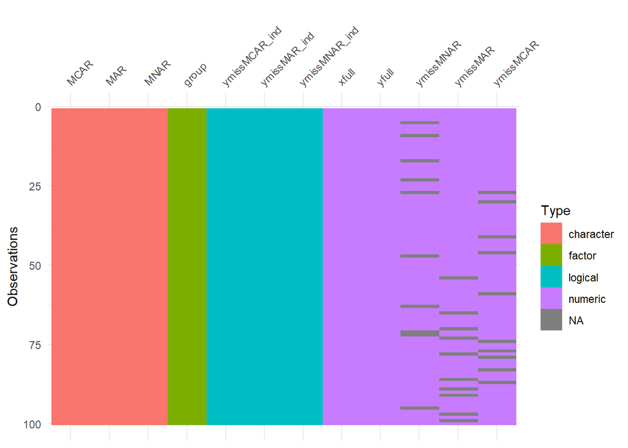

```r
data(toydataMiss, package = "VIM")
vis_dat(toydataMiss)
```

Wszstkie oprócz numeric można traktować jako faktory. Niezbyt ciekawy do imputacji. yMiss są tymi samymi kolumnami, z brakami w innych miejscach.

Odnoszę wrażenie, że jeśli to zauważyłem to imputowałbym ten zbiór idealnie. Dzięki temu można dostrzec bezsensowne modele imputacji. Z punktu widzenia człowieka NA z jednej kolumny wynika z drugiej, ale czy komputer będzie na tyle inteligentny?

# Metody imputacji w VIM

W VIM dostępne są 4 metody imputacji danych:

- k-Nearest Neighbors **kNN()**
- irmi **irmi()**
- Hot-deck **hotdeck()**
- Regression **regressionImp()**

### k-Nearest Neighbors imputation

Imputacja k-Nearest Neighbour bazuje na *odległości Gowera* charakterystycznej dla zmiennych numerycznych, kategorycznych, porządkowych, ciągłych oraz pół-ciągłych. W celu wyznaczenia tych odległości Gowera funkcja *kNN()* wykorzystuje również wbudowaną w pakiet funkcję *gowerD()* .

Parametry:

- *k* będący liczbą najbliższych sąsiadów, domyślnie 5.
- *dist_var* określa nazwy zmiennych służących do obliczenia odległości.
- *weights* = wagi przypisywane zmiennym podczas liczenia odległości. W przypadku domyślnej “auto” będą to wagi wynikające z algorytmu lasu losowego “ranger”.
- *numFun* = funkcja agregująca dla zm. ilościowych np. ‘mean’
- *catFun* = funkcja agregująca dla zm. jakościowych np. ‘maxCat’, ‘sampleCat’

Tutaj *maxCat()* i *sampleCat()* pochodzą z pakietu VIM i służą odpowiednio do wyboru kategorii najczęstszej albo losowej z zadanymi prawdopdoobieństwami.

W celu dobrego działania algorytmu należy uprzednio przygotować dane. Numeryczne wartości powinny być ustandaryzowane. Służy do tego również wbudowana w pakiet funkcja *prepare* .

Dzięki wyborze *dist_var* nie trzeba liczyć macierzy odległości dla całego zbioru danych, więc kNN jest dobre dla dużych zbiorów danych. Oczywiście hot-deck będzie szybszy, gdyż jest losową imputacją.

Warto wspomnieć, że dobrym zobrazowaniem decyzji jaką podejmuje algorytm 1-NN przy imputacji jest *diagram Woronoja* :

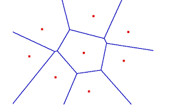

Przykładowe użycie algorytmu:

```r
#kNN
sleep_imp <- kNN(sleep)
head(sleep)
```

```
##    BodyWgt BrainWgt NonD Dream Sleep Span Gest Pred Exp Danger
## 1 6654.000   5712.0   NA    NA   3.3 38.6  645    3   5      3
## 2    1.000      6.6  6.3   2.0   8.3  4.5   42    3   1      3
## 3    3.385     44.5   NA    NA  12.5 14.0   60    1   1      1
## 4    0.920      5.7   NA    NA  16.5   NA   25    5   2      3
## 5 2547.000   4603.0  2.1   1.8   3.9 69.0  624    3   5      4
## 6   10.550    179.5  9.1   0.7   9.8 27.0  180    4   4      4
```

```r
head(sleep_imp)
```

```
##    BodyWgt BrainWgt NonD Dream Sleep Span Gest Pred Exp Danger BodyWgt_imp
## 1 6654.000   5712.0  3.2   0.8   3.3 38.6  645    3   5      3       FALSE
## 2    1.000      6.6  6.3   2.0   8.3  4.5   42    3   1      3       FALSE
## 3    3.385     44.5 12.8   2.4  12.5 14.0   60    1   1      1       FALSE
## 4    0.920      5.7 10.4   2.4  16.5  3.2   25    5   2      3       FALSE
## 5 2547.000   4603.0  2.1   1.8   3.9 69.0  624    3   5      4       FALSE
## 6   10.550    179.5  9.1   0.7   9.8 27.0  180    4   4      4       FALSE
##   BrainWgt_imp NonD_imp Dream_imp Sleep_imp Span_imp Gest_imp Pred_imp
## 1        FALSE     TRUE      TRUE     FALSE    FALSE    FALSE    FALSE
## 2        FALSE    FALSE     FALSE     FALSE    FALSE    FALSE    FALSE
## 3        FALSE     TRUE      TRUE     FALSE    FALSE    FALSE    FALSE
## 4        FALSE     TRUE      TRUE     FALSE     TRUE    FALSE    FALSE
## 5        FALSE    FALSE     FALSE     FALSE    FALSE    FALSE    FALSE
## 6        FALSE    FALSE     FALSE     FALSE    FALSE    FALSE    FALSE
##   Exp_imp Danger_imp
## 1   FALSE      FALSE
## 2   FALSE      FALSE
## 3   FALSE      FALSE
## 4   FALSE      FALSE
## 5   FALSE      FALSE
## 6   FALSE      FALSE
```

### irmi imputation

Skrót IRMI oznacza *iterative robust model-based imputation*. Metoda może zajmować się połączeniem zmiennych ciągłych, półciągłych, porządkowych i kategorycznych, wraz z outlierami.

IRMI buduje kolejkę modeli regresyjnych dla każdej zmiennej, które w razie potrzeby mogą też korzystać z pozostałych. Metoda na początku korzysta z prostej techniki imputacji, np. mediany. W każdej iteracji IRMI jedna zmienna jest używana jako zmienna odpowiedzi, a reszta służy jako regresory. Wyćwiczone na tej podstawie kolejne modele regresji liniowej służą potem wszystkie do reimputacji brakujących wartości. Proces jest powtarzany do osiągnięcia zbieżności lub określonej maksymalnej liczby iteracji (maxit). Według twórców tej imputacji, wykazał on w większości przypadków szybką zbieżność.

Przykład użycia:

```r
## irmi
form <- list(
  NonD = c('BodyWGT', 'BrainWGT'),
  Dream = c('BodyWGT', 'BrainWGT'),
  Sleep = c('BrainWGT')
) # kolumny od których ma zależeć imputacja

sleep_imp <- irmi(sleep, modelFormulas = form, trace = FALSE)

head(sleep)
```

```
##    BodyWgt BrainWgt NonD Dream Sleep Span Gest Pred Exp Danger
## 1 6654.000   5712.0   NA    NA   3.3 38.6  645    3   5      3
## 2    1.000      6.6  6.3   2.0   8.3  4.5   42    3   1      3
## 3    3.385     44.5   NA    NA  12.5 14.0   60    1   1      1
## 4    0.920      5.7   NA    NA  16.5   NA   25    5   2      3
## 5 2547.000   4603.0  2.1   1.8   3.9 69.0  624    3   5      4
## 6   10.550    179.5  9.1   0.7   9.8 27.0  180    4   4      4
```

```r
head(sleep_imp)
```

```
##    BodyWgt BrainWgt      NonD    Dream Sleep     Span Gest Pred Exp Danger
## 1 6654.000   5712.0  3.070297 0.706735   3.3 38.60000  645    3   5      3
## 2    1.000      6.6  6.300000 2.000000   8.3  4.50000   42    3   1      3
## 3    3.385     44.5 10.425627 2.081981  12.5 14.00000   60    1   1      1
## 4    0.920      5.7 13.361078 3.128523  16.5 30.43055   25    5   2      3
## 5 2547.000   4603.0  2.100000 1.800000   3.9 69.00000  624    3   5      4
## 6   10.550    179.5  9.100000 0.700000   9.8 27.00000  180    4   4      4
##   NonD_imp Dream_imp Sleep_imp Span_imp Gest_imp
## 1     TRUE      TRUE     FALSE    FALSE    FALSE
## 2    FALSE     FALSE     FALSE    FALSE    FALSE
## 3     TRUE      TRUE     FALSE    FALSE    FALSE
## 4     TRUE      TRUE     FALSE     TRUE    FALSE
## 5    FALSE     FALSE     FALSE    FALSE    FALSE
## 6    FALSE     FALSE     FALSE    FALSE    FALSE
```

### hot-deck imputation

Popularna i szeroko używana metoda, w której brakująca wartość jest uzupełniana z losowo wybranego, podobnego rekordu. W implementacji VIM przy hot-deckingu można określić zmienne do m.in. sortowania zbioru danych, budowania domen do imputacji lub sterowania wartościami NA. Ponadto na podstawie uzupełnianych kolumn można dodawać do bazy danych nowe z informacją, czy wartość kolumny w danym wierszu była imputowana (parametry *imp_var* i *imp_suffix*; domyślnie kolumny są dodawane z przyrostkiem *imp*).

Przykład użycia:

```r
#hot-deck
sleep_imp <- hotdeck(sleep, variable=c("NonD", "Dream", "Sleep", "Span", "Gest"), ord_var = "BodyWgt", domain_var = "Pred")
head(sleep)
```

```
##    BodyWgt BrainWgt NonD Dream Sleep Span Gest Pred Exp Danger
## 1 6654.000   5712.0   NA    NA   3.3 38.6  645    3   5      3
## 2    1.000      6.6  6.3   2.0   8.3  4.5   42    3   1      3
## 3    3.385     44.5   NA    NA  12.5 14.0   60    1   1      1
## 4    0.920      5.7   NA    NA  16.5   NA   25    5   2      3
## 5 2547.000   4603.0  2.1   1.8   3.9 69.0  624    3   5      4
## 6   10.550    179.5  9.1   0.7   9.8 27.0  180    4   4      4
```

```r
head(sleep_imp)
```

```
##    BodyWgt BrainWgt NonD Dream Sleep Span Gest Pred Exp Danger NonD_imp
## 1 6654.000   5712.0  2.1   1.8   3.3 38.6  645    3   5      3     TRUE
## 2    1.000      6.6  6.3   2.0   8.3  4.5   42    3   1      3    FALSE
## 3    3.385     44.5 10.9   3.6  12.5 14.0   60    1   1      1     TRUE
## 4    0.920      5.7 11.0   1.5  16.5  7.0   25    5   2      3     TRUE
## 5 2547.000   4603.0  2.1   1.8   3.9 69.0  624    3   5      4    FALSE
## 6   10.550    179.5  9.1   0.7   9.8 27.0  180    4   4      4    FALSE
##   Dream_imp Sleep_imp Span_imp Gest_imp
## 1      TRUE     FALSE    FALSE    FALSE
## 2     FALSE     FALSE    FALSE    FALSE
## 3      TRUE     FALSE    FALSE    FALSE
## 4      TRUE     FALSE     TRUE    FALSE
## 5     FALSE     FALSE    FALSE    FALSE
## 6     FALSE     FALSE    FALSE    FALSE
```

### regressionImp

Metoda imputuje brakujące wartości na podstawie modelu regresyjnego. Można w jej argumentach oprócz formuły określić rodzinę rozkładu jako parametr *family* - np. *binomial*, *Gamma*, *quasipoisson*, *normal* - lub odpornościowość regresji (parametr booleanowy *robust*). Metoda korzysta z funkcji *glm* lub, jeśli wskazujemy rodzinę *normal*, *lm*.

Imputacja przeprowadzana jest w miejscu. Podobnie jak *hotdeck*, funkcja *regressionImp* oferuje nowe kolumny opisujące status imputacji, których obsługa działa identycznie.

Przykładowe użycie *regressionImp* na zbiorze danych sleep:

```r
# regression
sleep_imp <- regressionImp(Dream+NonD+Span~BodyWgt+BrainWgt, data = sleep)

head(sleep)
```

```
##    BodyWgt BrainWgt NonD Dream Sleep Span Gest Pred Exp Danger
## 1 6654.000   5712.0   NA    NA   3.3 38.6  645    3   5      3
## 2    1.000      6.6  6.3   2.0   8.3  4.5   42    3   1      3
## 3    3.385     44.5   NA    NA  12.5 14.0   60    1   1      1
## 4    0.920      5.7   NA    NA  16.5   NA   25    5   2      3
## 5 2547.000   4603.0  2.1   1.8   3.9 69.0  624    3   5      4
## 6   10.550    179.5  9.1   0.7   9.8 27.0  180    4   4      4
```

```r
head(sleep_imp)
```

```
##    BodyWgt BrainWgt       NonD      Dream Sleep     Span Gest Pred Exp
## 1 6654.000   5712.0 -11.732867 -0.6897314   3.3 38.60000  645    3   5
## 2    1.000      6.6   6.300000  2.0000000   8.3  4.50000   42    3   1
## 3    3.385     44.5   8.987353  2.0132372  12.5 14.00000   60    1   1
## 4    0.920      5.7   9.017324  2.0148478  16.5 15.50179   25    5   2
## 5 2547.000   4603.0   2.100000  1.8000000   3.9 69.00000  624    3   5
## 6   10.550    179.5   9.100000  0.7000000   9.8 27.00000  180    4   4
##   Danger Dream_imp NonD_imp Span_imp
## 1      3      TRUE     TRUE    FALSE
## 2      3     FALSE    FALSE    FALSE
## 3      1      TRUE     TRUE    FALSE
## 4      3      TRUE     TRUE     TRUE
## 5      4     FALSE    FALSE    FALSE
## 6      4     FALSE    FALSE    FALSE
```

Oraz na zbiorach danych chorizonDL i SBS5242:

```r
print(chorizonDL[1:20, c("B", "Cu", "Fe")])
```

```
##     B   Cu    Fe
## 1  NA 41.6 15000
## 2  NA  8.0  8530
## 3  NA 23.0 18200
## 4  NA 23.7 10500
## 5  NA 23.9 20900
## 6  NA 16.0 11200
## 7  NA 16.3 16000
## 8  NA 36.0 17200
## 9  NA 17.7 13300
## 10  3 12.8 10500
## 11 NA 10.3  9490
## 12  3 31.1 26900
## 13  3 14.4  8570
## 14 NA 15.5  8590
## 15 NA 17.6 15300
## 16 NA 34.1 29700
## 17  4 27.8 17000
## 18  3 14.0 15700
## 19  4 29.4 21500
## 20  3 22.3  8780
```

```r
chorImp <- regressionImp(B~Cu+Fe, data=chorizonDL)
print(chorImp[1:20, c("B", "Cu", "Fe", "B_imp")])
```

```
##           B   Cu    Fe B_imp
## 1  3.151090 41.6 15000  TRUE
## 2  3.311473  8.0  8530  TRUE
## 3  3.556105 23.0 18200  TRUE
## 4  3.187422 23.7 10500  TRUE
## 5  3.669630 23.9 20900  TRUE
## 6  3.325957 16.0 11200  TRUE
## 7  3.545659 16.3 16000  TRUE
## 8  3.330692 36.0 17200  TRUE
## 9  3.400503 17.7 13300  TRUE
## 10 3.000000 12.8 10500 FALSE
## 11 3.324608 10.3  9490  TRUE
## 12 3.000000 31.1 26900 FALSE
## 13 3.000000 14.4  8570 FALSE
## 14 3.211128 15.5  8590  TRUE
## 15 3.495139 17.6 15300  TRUE
## 16 3.939705 34.1 29700  TRUE
## 17 4.000000 27.8 17000 FALSE
## 18 3.000000 14.0 15700 FALSE
## 19 4.000000 29.4 21500 FALSE
## 20 3.000000 22.3  8780 FALSE
```

```r
SBS <- as.data.frame(SBS5242)
print(SBS[50:70, c("PW", "Umsatz", "USB")])
```

```
##           PW    Umsatz        USB
## 50 3052.0877 3006.1601 20.9647108
## 51  207.8861  222.8790  1.2776885
## 52 2792.9466 2732.5810 25.0705172
## 53 1580.2334 1619.9130  0.0000000
## 54 4675.5097 4674.7445 18.2515156
## 55  203.9648  199.1293  0.0000000
## 56 3559.3499 3784.7059 17.8029896
## 57        NA 1161.8816  2.2177780
## 58 2909.3681 3069.7815 27.3126737
## 59  390.5857  383.5340  0.5444133
## 60 1442.1491 1392.1394 21.9711700
## 61 3348.9211 3301.7055 16.8010162
## 62 7406.4885 7049.2021 21.2807040
## 63  114.4889  111.3788  0.7772199
## 64 3263.1141 3390.8613 11.3825074
## 65        NA 6938.3307 22.4831651
## 66 3329.1523 3219.4516  9.8673295
## 67 3681.5285 3852.3416 61.4126247
## 68  386.2872  396.9051  1.5544052
## 69  324.4738  329.1504  5.7534287
## 70 9989.8243 9644.8340 78.2594827
```

```r
SBSImp <- regressionImp(PW~Umsatz+USB, data=SBS)
print(SBSImp[50:70, c("PW", "Umsatz", "USB", "PW_imp")])
```

```
##           PW    Umsatz        USB PW_imp
## 50 3052.0877 3006.1601 20.9647108  FALSE
## 51  207.8861  222.8790  1.2776885  FALSE
## 52 2792.9466 2732.5810 25.0705172  FALSE
## 53 1580.2334 1619.9130  0.0000000  FALSE
## 54 4675.5097 4674.7445 18.2515156  FALSE
## 55  203.9648  199.1293  0.0000000  FALSE
## 56 3559.3499 3784.7059 17.8029896  FALSE
## 57 1510.4355 1161.8816  2.2177780   TRUE
## 58 2909.3681 3069.7815 27.3126737  FALSE
## 59  390.5857  383.5340  0.5444133  FALSE
## 60 1442.1491 1392.1394 21.9711700  FALSE
## 61 3348.9211 3301.7055 16.8010162  FALSE
## 62 7406.4885 7049.2021 21.2807040  FALSE
## 63  114.4889  111.3788  0.7772199  FALSE
## 64 3263.1141 3390.8613 11.3825074  FALSE
## 65 7367.2511 6938.3307 22.4831651   TRUE
## 66 3329.1523 3219.4516  9.8673295  FALSE
## 67 3681.5285 3852.3416 61.4126247  FALSE
## 68  386.2872  396.9051  1.5544052  FALSE
## 69  324.4738  329.1504  5.7534287  FALSE
## 70 9989.8243 9644.8340 78.2594827  FALSE
```

# Wizualizacja braków danych w VIM

VIM udostępnia nam również funkcje do wykresów, dzięki którym będziemy mogli inaczej zwizualizować braki danych.

### marginMatrix

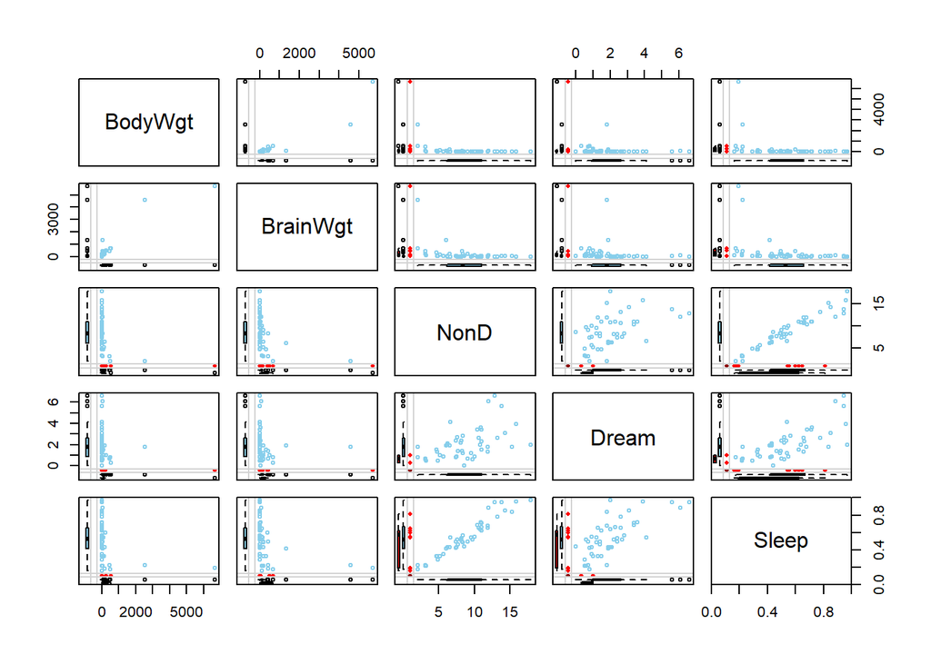

```r
x <- sleep[, 1:5]
marginmatrix(x)
```

### ScatterJitt

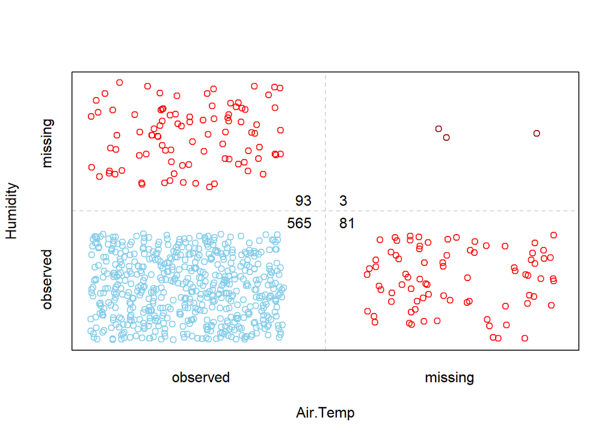

```r
data(tao, package = 'VIM')
scattJitt(tao[, c("Air.Temp", "Humidity")])
```

### histMiss

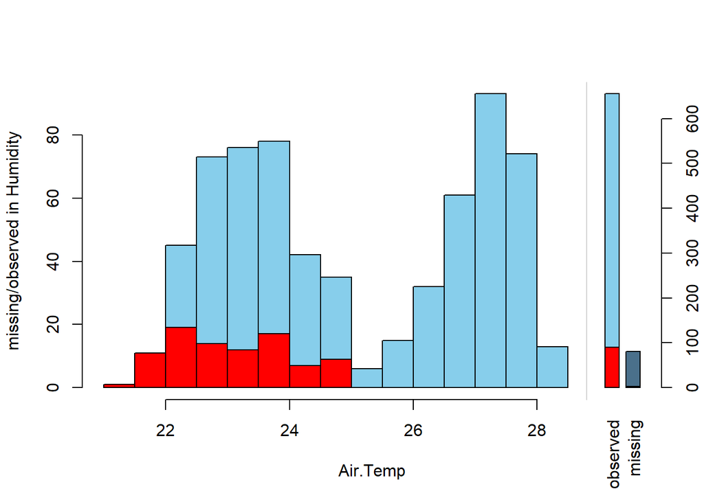

```r
x <- tao[, c("Air.Temp", "Humidity")]
histMiss(x, only.miss = FALSE)
```

### scattMiss

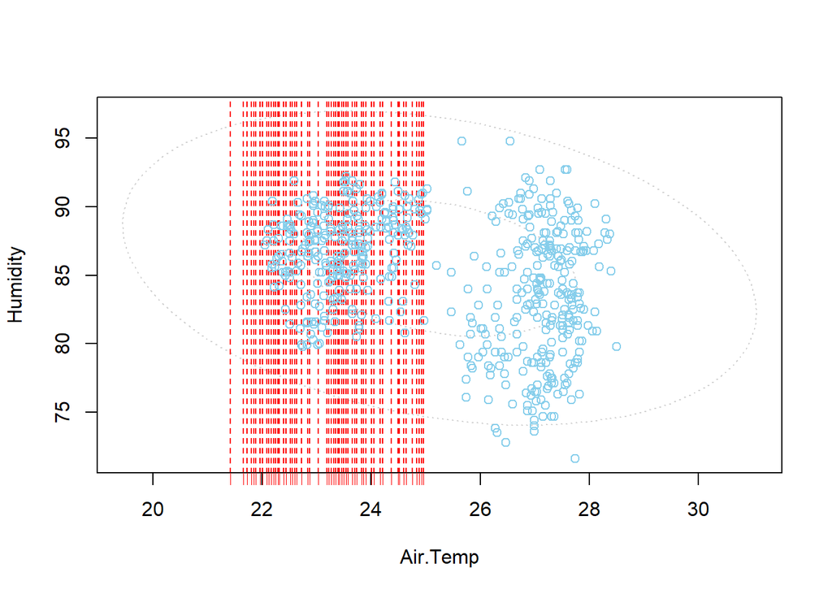

```r
scattMiss(x)
```

### barMiss

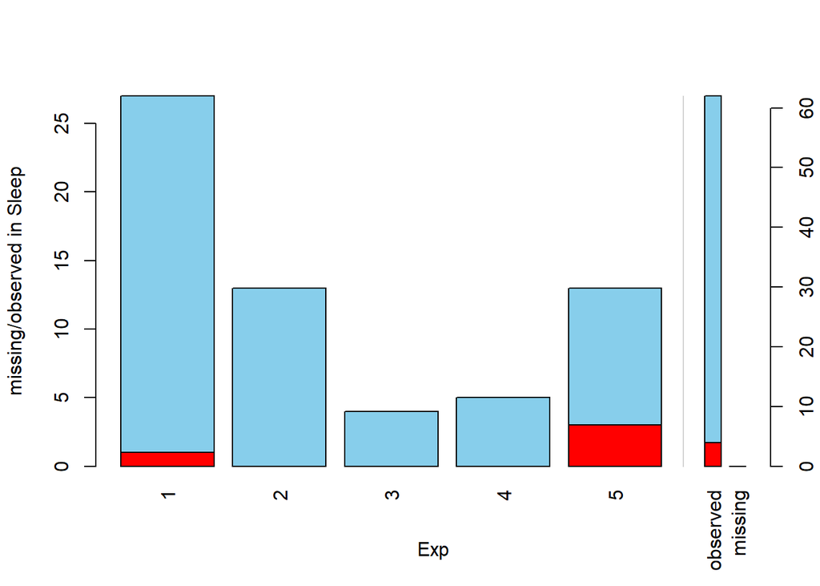

```r
x <- sleep[, c("Exp", "Sleep")]
barMiss(x, only.miss = FALSE)
```

```r
# mało intuicyjna, pierwszą kolumnę traktuje jako grupy, drugą do zliczania obserwacji
```

### spineMiss

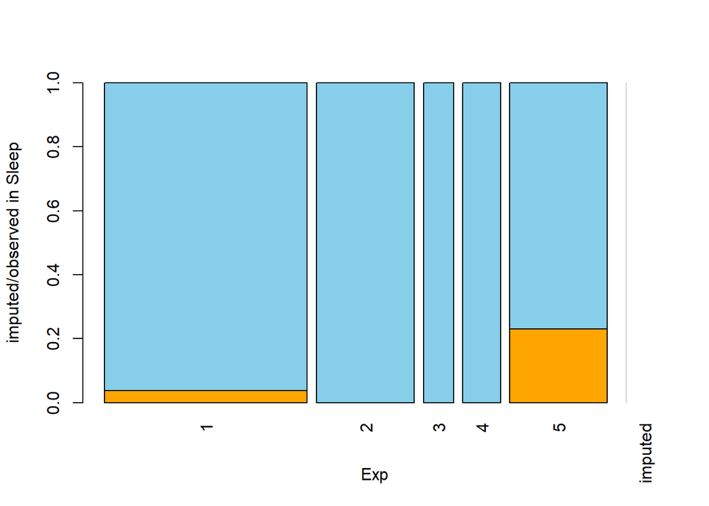

```r
spineMiss(kNN(x), delimiter = "_imp")
```

# Dodatki

W VIM dostępne są również funkcje pomocnicze. Z niektórych tych funkcji korzystamy przy wstępnej obróbce, a niektóre liczą dla nas ciekawe statystyki dotyczące braków danych. Inne z kolei operują na kolorach.

### gapMiss()

FUnkcja oblicza różne statystyki dla długości sekwencji NA w wektorze.

```r
set.seed(54)
v <- rpois(100, lambda = 1) # z rozkładu Poissona
v[3:5] <- NA
v[6:9] <- NA
v[sample(100, 20)] <- NA

gapMiss(v, what = median) # mediana długości sekwencji NA
```

```
## [1] 1
```

```r
gapMiss(v, what = function(x) mean(x, trim = 0.05)) # średnia ucięta
```

```
## [1] 1.529412
```

```r
gapMiss(v, what = function(x) psych::harmonic.mean(x))
```

```
## [1] 1.160976
```

### sampleCat()

Funkcja ta wyciąga level z faktora. Przyporządkując wagi odpowiednim obserwacjom, oblicza odpowiednie prawdopodobieństwa.

```r
v <- as.factor(c(1,1,2,2,3,3))

set.seed(800)
sampleCat(v, weights = c(0.1, 0.1, 0.5, 0.5, 2, 2))
```

```
## [1] "2"
```

```r
sampleCat(v, weights = c(0.1, 0.1, 0.5, 0.5, 2, 2))
```

```
## [1] "3"
```

```r
sampleCat(v, weights = c(0.1, 0.1, 0.5, 0.5, 2, 2))
```

```
## [1] "3"
```

```r
sampleCat(v, weights = c(0.1, 0.1, 0.5, 0.5, 2, 2))
```

```
## [1] "3"
```

```r
sampleCat(v, weights = c(10, 10, 0.5, 0.5, 2, 2)) # 1 z dużą wagą
```

```
## [1] "1"
```

```r
sampleCat(v, weights = c(10, 10, 0.5, 0.5, 2, 2)) # 1 z dużą wagą
```

```
## [1] "1"
```

### prepare()

Funkcja do transformacji i standaryzacji danych.

Transofmracja i standaryzacja są ważną obróbką wstępną w celu późniejszego zastosowania algorytmu k Nearest-Neighbors czy to do imputacji albo do uczenia nienadzorowanego w analizie skupień/klasteryzacji.

```r
data(sleep, package = "VIM")
x <- sleep[, c("BodyWgt", "BrainWgt")]

head(x,10)
```

```
##     BodyWgt BrainWgt
## 1  6654.000   5712.0
## 2     1.000      6.6
## 3     3.385     44.5
## 4     0.920      5.7
## 5  2547.000   4603.0
## 6    10.550    179.5
## 7     0.023      0.3
## 8   160.000    169.0
## 9     3.300     25.6
## 10   52.160    440.0
```

```r
head(prepare(x, scaling = "robust", transformation = "logarithm"),10)
```

```
##        BodyWgt   BrainWgt
## 1   2.29654423  2.0656518
## 2  -0.36479406 -0.3419737
## 3   0.00384425  0.3373974
## 4  -0.39000221 -0.3941625
## 5   2.00622319  1.9888083
## 6   0.34751616  0.8338863
## 7  -1.50523403 -1.4423422
## 8   1.16954595  0.8124287
## 9  -0.00384425  0.1405737
## 10  0.83068522  1.1530634
```

### countInf(), countNA()

Funkcja zlicza Inf lub NA w wektorze. Nie działa dla ramek danych :( .

```r
dane <- c(5,Inf,-Inf, 5,-2, 5, Inf, 0, -Inf, 5, NA, NA, Inf, 6, 5, 9)
countInf(dane) # 5
```

```
## [1] 5
```

```r
countNA(dane) # 2
```

```
## [1] 2
```

### colSequence()

Oblicza kolory pośrednie między 2 kolorami. Model przestrzeni barw HCL lub RGB.

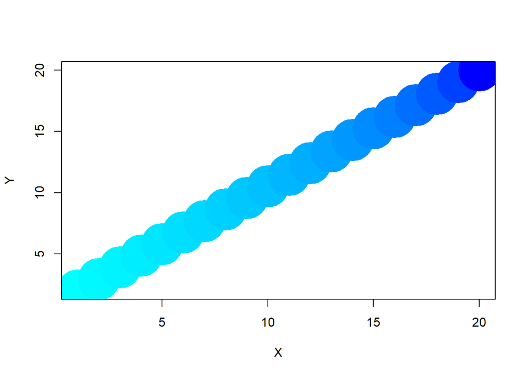

```r
p <- seq(0,1,length = 20)
cs <- colSequence(p, "cyan", "blue")
plot(x = 1:20, y = seq(2,20,length = 20), lty = 3, col = cs, cex = 2, lwd = 40, ylab = "Y", xlab = "X")
```

Widzimy kolory od turkusowego do niebieskiego.

### alphablend()

Funkcja zmienia przezroczystość naszego koloru w skali 0-1. Zwraca kod heksadecymalny koloru

```r
alphablend("red", 0.1)
```

```
## [1] "#FF00001A"
```

Przykład przezroczystości

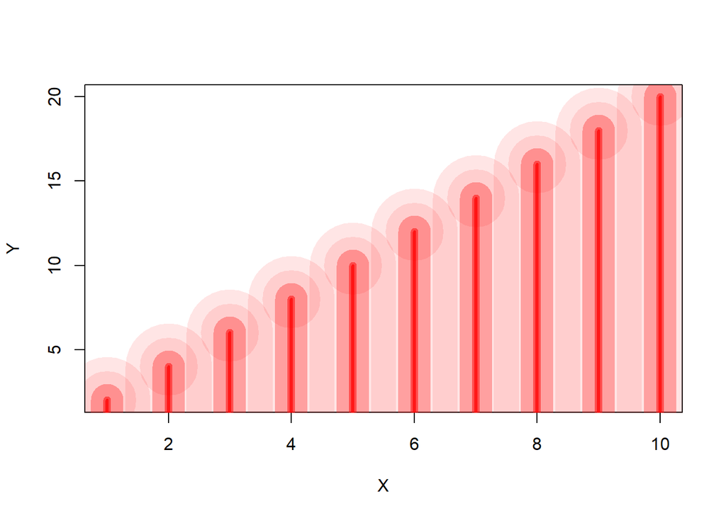

```r
plot(x = 1:10, y = seq(2,20,2), lty = 3, col = alphablend("red", 0.1), cex = 2, lwd = 40, ylab = "Y", xlab = "X")
lines(x = 1:10, y = seq(2,20,2), lty = 1, col = alphablend("red", 0.1), type = "h", lw = 80)
lines(x = 1:10, y = seq(2,20,2), lty = 1, col = alphablend("red", 0.3), type = "h", lw = 30)
lines(x = 1:10, y = seq(2,20,2), lty = 1, col = alphablend("red", 0.5), type = "h", lw = 7)
lines(x = 1:10, y = seq(2,20,2), lty = 1, col = alphablend("red", 0.7), type = "h", lw = 3)
```

Kolory nakładając się na wykresie zmniejszają swoją przezroczystość.